# hw4

Alexandra Bushby

2/9/2018

The data I am using I got from Statistics Canada. This data is the incidence of cancers in various provinces from 2011 to 2015.

**BMB**:

- were these data presented in a table originally? (that was the intent of the assignment - but drawing graphs is still good)

BMB: it’s best practice to name your chunks (so you can tell which ones fail/take a long time/etc.)

BMB: a more efficient pipeline -

```r
inc_lab <- "Cancer incidence (rate per 100,000 population) (24)"
data1 <- read_csv("cancer.csv") %>%
    mutate(Geography=trimws(Geography)) %>%
    filter(Characteristics==inc_lab) %>%
    select(-Characteristics) %>%
    gather(Year, Cases, -Geography, convert=TRUE)
```

```r
region_dat <- read_csv(file="
Geography,Region
Newfoundland and Labrador,Atlantic
Nova Scotia,Atlantic
Prince Edward Island,Atlantic
New Brunswick,Atlantic
Ontario,Ontario
British Columbia,British Columbia
Manitoba,Prairie
Saskatchewan,Prairie
Alberta,Prairie
Yukon,North
Northwest Territories,North
Nunavut,North
")
data2 <- data1 %>% full_join(region_dat,by="Geography")
```

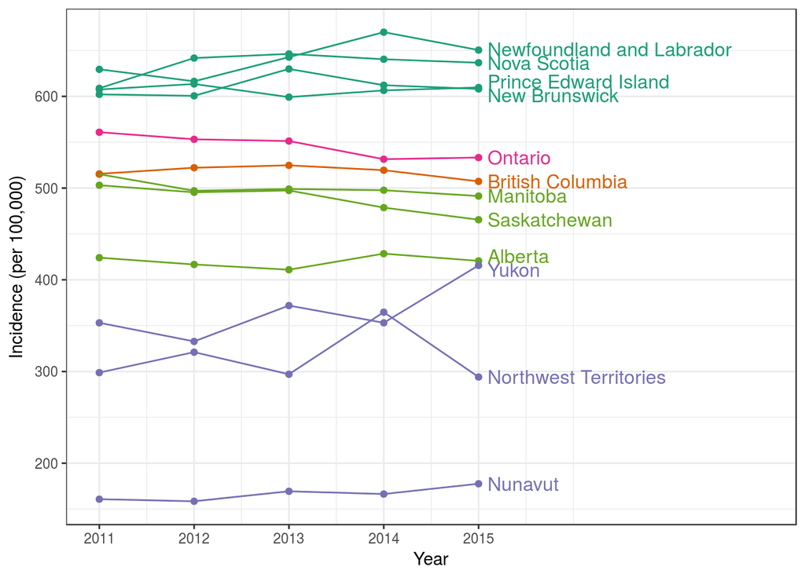

```r
## BMB: if you put parentheses at the beginning (as you have),
##   you can put + signs at the beginnings of lines -- makes it
##   easier to add/remove/comment out lines
gg1 <- (ggplot(data2, aes(Year, Cases, colour=Region, group=Geography))
    + geom_point()
    + geom_line()
    + geom_dl(aes(label=Geography),
              method = list(dl.trans(x=x+0.2),"last.qp"))
    + theme(legend.position="none")
    + labs(x="Year", y="Incidence (per 100,000)")
    + scale_x_continuous(breaks=2011:2015,limits=c(2011,2018))
    + scale_colour_brewer(palette="Dark2")
)
plot(gg1)
```

I was wondering how I could spread the names out so they aren’t overlapping? Could you help me with that?

BMB:

- for positioning, see `?last.bumpup`, `?last.qp`. Also, `dl_trans()` gives a little more space between the endpoints and the labels
- The only disadvantage to this layout (that I can see) is that the year-to-year differences are swamped by the between-region differences. There are a variety of different ways to handle this (split into facets according to incidence category; split into all separate facets; normalize incidence by starting incidence …)
- questions about data/interpretation: is this for all types of cancers? It surprises me that there’s such a huge range of incidence across regions: also, seems to cluster in larger regions (Atlantic Canada is highest, the north is lowest). Does this have to with reporting? Occupational exposure? Other causes of mortality intervening?
- to emphasize this, I added information about region and coloured the lines accordingly (could have left BC with the other Western provinces, I guess)
- where’s Quebec?